# Homework 2

Author

Nicole Friedl

Published

February 1, 2025

## Part 1: Data Analysis

A researcher wants to understand the effects of daily stressors, social interaction, and year of undergraduate study on stress levels in undergraduate programs at University of Tatooine. To investigate this, they recruited 150 undergraduate students from the university. Each participant was first asked which year of undergraduate study they were from (freshman or senior). Each participant was then asked how bad their day was and to rate it from 1 (not bad at all) to 5 (terrible). Then, each participant was asked how much social interaction they have been having (on average in a given day) and to rate it from 1 (not at all) to 5 (a lot). Finally, each participant was asked to self-report the levels of stress they have been experiencing in the last one month on a scale of 1 (no stress at all) to 51 (extremely so). The researcher predict that the interaction effect of having a bad day, the amount of social interaction, and year of undergraduate study will significantly predict stress levels, such that the impact of a bad day on stress will differ based on both the amount of social interaction and whether the participant is a freshman or senior. The codebook for the dataset is below. Codebook for the “hw_16_data.csv”

**Codebook:**

- `sub_id`
- `bad_day`
- `talk`
- `stress`

```r
options(conflicts.policy = "depends.ok")
library(tidyverse)
library(broom)
library(skimr)
library(readxl)
library(janitor)
library(dplyr)
library(ggplot2)

theme_set(theme_classic())

path_data <- "homework/data"
devtools::source_url("https://github.com/jjcurtin/lab_support/blob/main/case_analysis.R?raw=true")

peta <- function(compact, augmented) {
  sse_c <- sum(residuals(compact)^2)
  sse_a <- sum(residuals(augmented)^2)

  (sse_c - sse_a)/sse_c
}
```

### 1. Data preparation

#### a. Read in your data (And convert names to snake case if needed. Use a function to check whether your case conversion was successful.)

```r
data <- read_csv(here::here(path_data, "hw_16_data.csv"),
              show_col_types = FALSE) |>
  janitor::clean_names()
  glimpse(data)
```

```
Rows: 150
Columns: 5
$ sub_id  <dbl> 1, 2, 3, 4, 5, 6, 7, 8, 9, 10, 11, 12, 13, 14, 15, 16, 17, 18,…
$ class   <chr> "freshman", "senior", "senior", "senior", "freshman", "freshma…
$ bad_day <dbl> 3, 1, 1, 3, 4, 2, 5, 2, 3, 2, 4, 2, 4, 4, 4, 1, 1, 5, 4, 2, 4,…
$ talk    <dbl> 2, 4, 3, 5, 2, 2, 3, 4, 4, 1, 1, 1, 3, 4, 3, 5, 1, 2, 5, 1, 4,…
$ stress  <dbl> 39, 31, 24, 20, 42, 28, 19, 17, 30, 21, 28, 28, 18, 16, 39, 25…
```

#### b. Explore your data using at least two functions we covered last semester (remember to account for missing values, if any).

```r
glimpse(data)
```

```
Rows: 150
Columns: 5
$ sub_id  <dbl> 1, 2, 3, 4, 5, 6, 7, 8, 9, 10, 11, 12, 13, 14, 15, 16, 17, 18,…
$ class   <chr> "freshman", "senior", "senior", "senior", "freshman", "freshma…
$ bad_day <dbl> 3, 1, 1, 3, 4, 2, 5, 2, 3, 2, 4, 2, 4, 4, 4, 1, 1, 5, 4, 2, 4,…
$ talk    <dbl> 2, 4, 3, 5, 2, 2, 3, 4, 4, 1, 1, 1, 3, 4, 3, 5, 1, 2, 5, 1, 4,…
$ stress  <dbl> 39, 31, 24, 20, 42, 28, 19, 17, 30, 21, 28, 28, 18, 16, 39, 25…
```

```r
skim(data)
```

Data summary

| Name | data |
| --- | --- |
| Number of rows | 150 |
| Number of columns | 5 |
| _______________________ |  |
| Column type frequency: |  |
| character | 1 |
| numeric | 4 |
| ________________________ |  |
| Group variables | None |

**Variable type: character**

| skim_variable | n_missing | complete_rate | min | max | empty | n_unique | whitespace |
| --- | --- | --- | --- | --- | --- | --- | --- |
| class | 0 | 1 | 6 | 8 | 0 | 2 | 0 |

**Variable type: numeric**

| skim_variable | n_missing | complete_rate | mean | sd | p0 | p25 | p50 | p75 | p100 | hist |
| --- | --- | --- | --- | --- | --- | --- | --- | --- | --- | --- |
| sub_id | 0 | 1 | 75.50 | 43.45 | 1 | 38.25 | 75.5 | 112.75 | 150 | ▇▇▇▇▇ |
| bad_day | 0 | 1 | 2.95 | 1.29 | 1 | 2.00 | 3.0 | 4.00 | 5 | ▅▇▇▇▅ |
| talk | 0 | 1 | 2.57 | 1.20 | 1 | 2.00 | 2.0 | 3.75 | 5 | ▆▇▆▅▂ |
| stress | 0 | 1 | 30.15 | 10.00 | 1 | 23.00 | 30.0 | 38.00 | 51 | ▁▅▇▇▃ |

After inspection, there are no missing values. I am not concerned.

#### c. Make sure your variables are appropriately classed. This should include, for instance, making sure there aren’t any numeric variables that were accidentally read in ascharacters

```r
str(data)
```

```
spc_tbl_ [150 × 5] (S3: spec_tbl_df/tbl_df/tbl/data.frame)
 $ sub_id : num [1:150] 1 2 3 4 5 6 7 8 9 10 ...
 $ class  : chr [1:150] "freshman" "senior" "senior" "senior" ...
 $ bad_day: num [1:150] 3 1 1 3 4 2 5 2 3 2 ...
 $ talk   : num [1:150] 2 4 3 5 2 2 3 4 4 1 ...
 $ stress : num [1:150] 39 31 24 20 42 28 19 17 30 21 ...
 - attr(*, "spec")=
  .. cols(
  ..   sub_id = col_double(),
  ..   class = col_character(),
  ..   bad_day = col_double(),
  ..   talk = col_double(),
  ..   stress = col_double()
  .. )
 - attr(*, "problems")=<externalptr>
```

Looks good!

### d. Create three quick-and-dirty bivariate plots of the researchers’ three predictor variables on the outcome variable, reported levels of stress. Write a brief description of what you see in these plots.

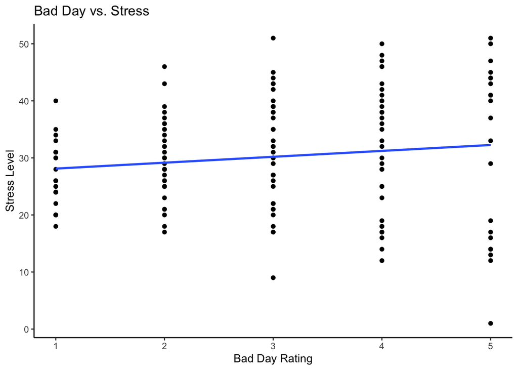

```r
ggplot(data, aes(x = bad_day, y = stress)) +
  geom_point() +
  geom_smooth(method = "lm", se = FALSE) +
  labs(title = "Bad Day vs. Stress", x = "Bad Day Rating", y = "Stress Level")
```

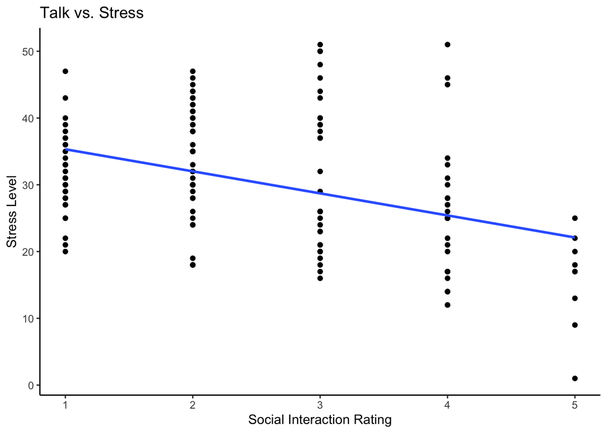

```r
ggplot(data, aes(x = talk, y = stress)) +
  geom_point() +
  geom_smooth(method = "lm", se = FALSE) +
  labs(title = "Talk vs. Stress", x = "Social Interaction Rating", y = "Stress Level")
```

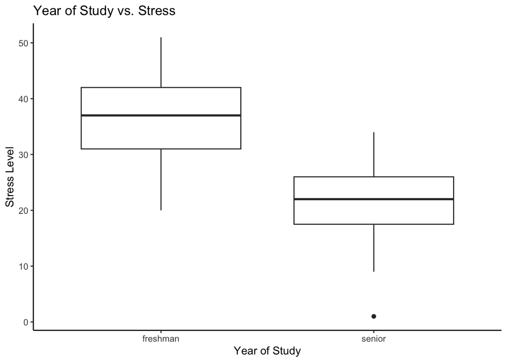

```r
ggplot(data, aes(x = as.factor(class), y = stress)) +
  geom_boxplot() +
  labs(title = "Year of Study vs. Stress", x = "Year of Study", y = "Stress Level")
```

Talk vs stress: suggests that higher levels of social interaction are associated with lower levels of stress. Bad day vs stress: The line slopes slightly upward, suggesting a positive correlation between the Bad Day Rating and Stress Level. As the Bad Day Rating increases (meaning a worse day), the Stress Level tends to also increase. Year of study vs stress: The plot visually suggests that freshmen tend to experience higher stress levels than seniors.

### 2. Test the appropriate model for the researchers’ original hypothesis. Suppose you were testing the effect of ‘class’, ‘bad_day’, and ‘talk’ and their interaction on the ‘stress’ reported by the undergraduate participants. Write out what your equation would look like and describe which coefficients correspond to the various main effects and the interaction effects.Run the model.Generate F-statistics for each predictor. Generate partial eta-squared values for each predictor. Generate 95% confidence intervals for each predictor

stress=β0 + β1 * class+ β2 * bad_day+β3 * talk+ β4 * (class×bad_day)+ β5 * (class×talk)+ β6 * (bad_day×talk) + β7 * (class×bad_day×talk) + ϵ

β0 is the intercept (the baseline stress level for freshmen with no bad day and no social interaction), β1 is the coefficient for the class variable (the difference in stress between freshmen and seniors), β2 is the coefficient for bad_day (the effect of having a bad day on stress), β3 is the coefficient for talk (the effect of social interaction on stress), β4, β5, and β6 represent the interactions between the variables, β7 represents the three-way interaction effect of class, bad_day, and talk on stress, ϵ is the error term.

#### a. Write a formal summary of the results, as if you were giving this report to a scientific colleague. In addition to a brief introduction to the study and its goals, your report should include appropriate b values, F-statistics (including degrees of freedom), 95% confidence intervals, and partial eta-squared values. You should report every predictor (aside from the intercept), regardless of significance. State whether the researchers’ hypothesis was confirmed.

```r
compact <- compact_model <- lm(stress ~ class * bad_day + talk, data = data)
m_1 <- lm(stress ~ class * bad_day * talk, data = data)

summary(m_1)
```

```
Call:
lm(formula = stress ~ class * bad_day * talk, data = data)

Residuals:
     Min       1Q   Median       3Q      Max
-10.6126  -3.2974   0.0671   3.1129  10.7774

Coefficients:
                         Estimate Std. Error t value Pr(>|t|)
(Intercept)               20.2350     3.5643   5.677 7.45e-08 ***
classsenior                0.1035     5.7548   0.018   0.9857
bad_day                    2.4029     1.1284   2.129   0.0349 *
talk                       4.4668     1.8595   2.402   0.0176 *
classsenior:bad_day        0.1244     2.0069   0.062   0.9507
classsenior:talk          -1.9797     2.2823  -0.867   0.3872
bad_day:talk               0.1041     0.5744   0.181   0.8565
classsenior:bad_day:talk  -1.5260     0.7336  -2.080   0.0393 *
---
Signif. codes:  0 '***' 0.001 '**' 0.01 '*' 0.05 '.' 0.1 ' ' 1

Residual standard error: 4.733 on 142 degrees of freedom
Multiple R-squared:  0.7865,    Adjusted R-squared:  0.776
F-statistic: 74.72 on 7 and 142 DF,  p-value: < 2.2e-16
```

```r
summary(compact)
```

```
Call:
lm(formula = stress ~ class * bad_day + talk, data = data)

Residuals:
     Min       1Q   Median       3Q      Max
-16.3870  -3.7036   0.0198   3.7024  14.5281

Coefficients:
                    Estimate Std. Error t value Pr(>|t|)
(Intercept)          25.0402     1.8785  13.330  < 2e-16 ***
classsenior           0.1437     2.3688   0.061  0.95170
bad_day               2.8742     0.5058   5.683 7.03e-08 ***
talk                  1.4575     0.5054   2.884  0.00453 **
classsenior:bad_day  -5.8911     0.7161  -8.227 1.00e-13 ***
---
Signif. codes:  0 '***' 0.001 '**' 0.01 '*' 0.05 '.' 0.1 ' ' 1

Residual standard error: 5.556 on 145 degrees of freedom
Multiple R-squared:  0.6996,    Adjusted R-squared:  0.6913
F-statistic: 84.42 on 4 and 145 DF,  p-value: < 2.2e-16
```

```r
anova(m_1)
```

```
Analysis of Variance Table

Response: stress
                    Df Sum Sq Mean Sq  F value    Pr(>F)
class                1 8184.1  8184.1 365.3256 < 2.2e-16 ***
bad_day              1    5.4     5.4   0.2389   0.62574
talk                 1  144.4   144.4   6.4437   0.01221 *
class:bad_day        1 2089.2  2089.2  93.2601 < 2.2e-16 ***
class:talk           1 1076.5  1076.5  48.0534 1.341e-10 ***
bad_day:talk         1  121.3   121.3   5.4137   0.02139 *
class:bad_day:talk   1   96.9    96.9   4.3268   0.03931 *
Residuals          142 3181.1    22.4
---
Signif. codes:  0 '***' 0.001 '**' 0.01 '*' 0.05 '.' 0.1 ' ' 1
```

```r
anova(compact)
```

```
Analysis of Variance Table

Response: stress
               Df Sum Sq Mean Sq  F value    Pr(>F)
class           1 8184.1  8184.1 265.1343 < 2.2e-16 ***
bad_day         1    5.4     5.4   0.1734   0.67773
talk            1  144.4   144.4   4.6765   0.03222 *
class:bad_day   1 2089.2  2089.2  67.6834 1.004e-13 ***
Residuals     145 4475.8    30.9
---
Signif. codes:  0 '***' 0.001 '**' 0.01 '*' 0.05 '.' 0.1 ' ' 1
```

```r
peta(compact, m_1)
```

```
[1] 0.2892676
```

```r
confint(m_1)
```

```
                              2.5 %      97.5 %
(Intercept)               13.188967 27.28095938
classsenior              -11.272660 11.47967198
bad_day                    0.172237  4.63359147
talk                       0.790956  8.14255696
classsenior:bad_day       -3.842912  4.09164893
classsenior:talk          -6.491500  2.53201289
bad_day:talk              -1.031407  1.23952822
classsenior:bad_day:talk  -2.976271 -0.07577148
```

```r
confint(compact)
```

```
                         2.5 %    97.5 %
(Intercept)         21.3273012 28.753037
classsenior         -4.5380878  4.825578
bad_day              1.8745508  3.873843
talk                 0.4586058  2.456456
classsenior:bad_day -7.3064073 -4.475831
```

The study aimed to investigate the effects of undergraduate year level (class), daily stressors (bad day), and social interaction (talk) on stress levels reported by students at the university. Specifically, the researchers hypothesized that the interaction of these variables would significantly predict stress, such that the impact of a bad day on stress would differ based on both the amount of social interaction and whether the participant was a freshman or senior. To test this hypothesis, two models were fit: a full model that included the three-way interaction, and a more compact model that included only the main effects and key interactions.

Full Model Results: The full model included the main effects of class, bad_day, and talk, as well as their two-way and three-way interactions. The results of the linear model are summarized here:

Class (Freshman vs. Senior):

b = 0.1035, SE = 5.7548, t = 0.018, p = 0.9857 This suggests no significant difference in stress between freshmen and seniors. 95% CI: [-11.27, 11.48]

Bad Day:

b = 2.4029, SE = 1.1284, t = 2.129, p = 0.0349 The effect of having a bad day on stress is significant, with each bad day increasing reported stress by about 2.4 units. 95% CI: [0.17, 4.63]

Class × Bad Day Interaction:

b = 0.1244, SE = 2.0069, t = 0.062, p = 0.9507 The interaction between class and bad day is not significant. 95% CI: [-3.84, 4.09]

Class × Talk Interaction:

b = -1.9797, SE = 2.2823, t = -0.867, p = 0.3872 The interaction between class and talk is not significant. 95% CI: [-6.49, 2.53]

Bad Day × Talk Interaction:

b = 0.1041, SE = 0.5744, t = 0.181, p = 0.8565 The interaction between bad day and talk is not significant. 95% CI: [-1.03, 1.24]

Class × Bad Day × Talk Interaction:

b = -1.5260, SE = 0.7336, t = -2.080, p = 0.0393 The three-way interaction between class, bad day, and talk is significant. This suggests that the impact of bad days on stress is moderated by both class and the level of social interaction. 95% CI: [-2.98, -0.08]

Model Fit:

F-statistic = 74.72, df = 7, 142, p-value < 2.2e-16 R-squared = 0.7865, Adjusted R-squared = 0.776 Compact Model Results: The compact model included the main effects of class, bad_day, and talk, and the interaction between class and bad_day. The results are summarized here:

Class (Freshman vs. Senior):

#### 4. Publication graph yay!!!

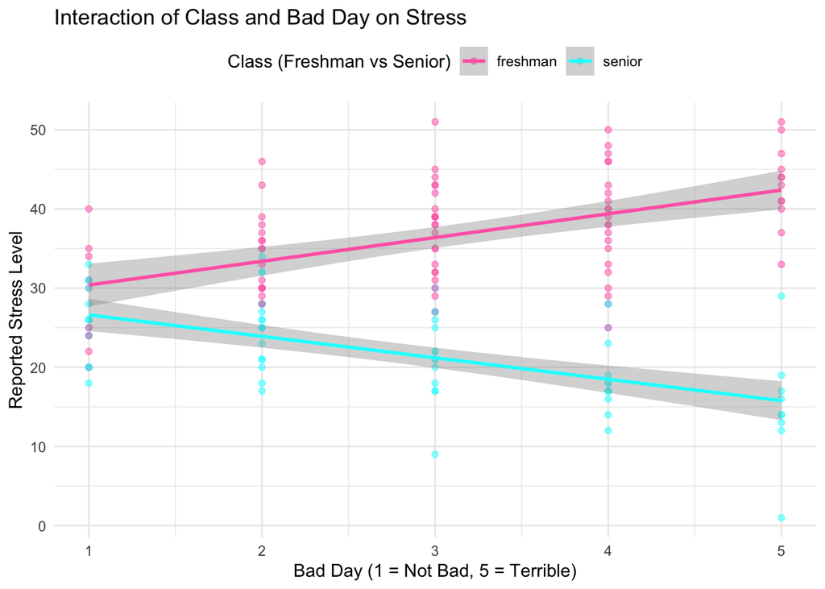

```r
ggplot(data, aes(x = bad_day, y = stress, color = class, group = class)) +
  geom_point(alpha = 0.5) +
  geom_smooth(method = "lm", se = TRUE) +
  labs(title = "Interaction of Class and Bad Day on Stress",
       x = "Bad Day (1 = Not Bad, 5 = Terrible)",
       y = "Reported Stress Level",
       color = "Class (Freshman vs Senior)") +
  scale_color_manual(values = c("hotpink", "cyan")) +
  theme_minimal() +
  theme(legend.position = "top")
```

#### a. Are there any topics in particular that you are feeling less confident about from 610? We will do our best to read these responses and incorporate review of these topics throughout the semester

I think I feel confident for the most part. I do think I want to review power transformations, why do we use them? When do we use them?

#### b. How long did this assignment take?

2 hours.